# MTH6139 Time Series - Forecasting CO2 Levels with Prophet: Global Trends and a Romania Perspective

Coursework 1 – Time Series

Alexia-Matia Tig

Spring term 2026

# **Introduction**

In this project, I use the built-in CO2 dataset in R and apply the Prophet model to forecast future **CO2 levels**. The aim is to identify the main trend in the data and examine whether there is any seasonal pattern over time.

# **Data and model explanation**

## 1.The CO2 Time Series

First, the time series data is converted into a format that Prophet can use. Prophet requires two columns: ds for the date and y for the observed values.

```r
library(prophet)
library(zoo)
# The following code is converting the build-in CO2 time series into the format Prophet requires

co2_data <- data.frame(
  ds = as.Date(as.yearmon(time(co2))),
  y = as.numeric(co2)
)

head(co2_data)
```

```
##           ds      y
## 1 1959-01-01 315.42
## 2 1959-02-01 316.31
## 3 1959-03-01 316.50
## 4 1959-04-01 317.56
## 5 1959-05-01 318.13
## 6 1959-06-01 318.00
```

The model is fitted to the data, in order to learn patterns from the data that we have. This will detect trend like how CO2 increased over time, seasonality, like a monthly pattern and change points which will show us where trends shifts.

```r
ts_model <- prophet(co2_data)
```

```
## Disabling weekly seasonality. Run prophet with weekly.seasonality=TRUE to override this.
```

```
## Disabling daily seasonality. Run prophet with daily.seasonality=TRUE to override this.
```

This line creates a calendar for the future (48 months = 4 years), basically this step generates future dates that allow the model to produce forecasts.

```r
future_dates <- make_future_dataframe(ts_model, periods = 48, freq = 'month')
```

This line asks Prophet to fill in that calendar with its predictions about CO2 values

```r
forecast <- predict(ts_model, future_dates)
```

## 2.Plots

The following line will generate the graph in order to have a visualise of past and future data:

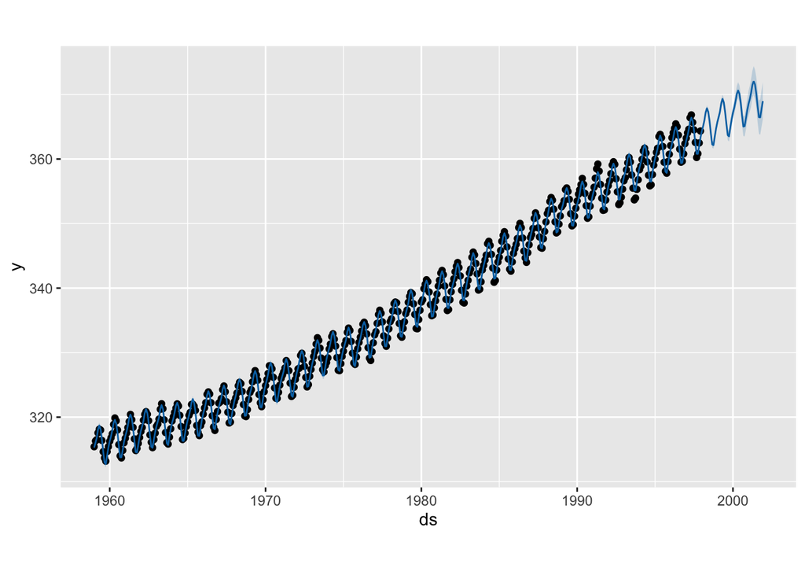

```r
plot(ts_model, forecast)
```

The forecast shows that CO2 levels are expected to continue increasing in the future. The model also captures the regular seasonal fluctuations observed in the historical data.

```r
summary(co2_data$y)
```

```
##    Min. 1st Qu.  Median    Mean 3rd Qu.    Max.
##   313.2   323.5   335.2   337.1   350.3   366.8
```

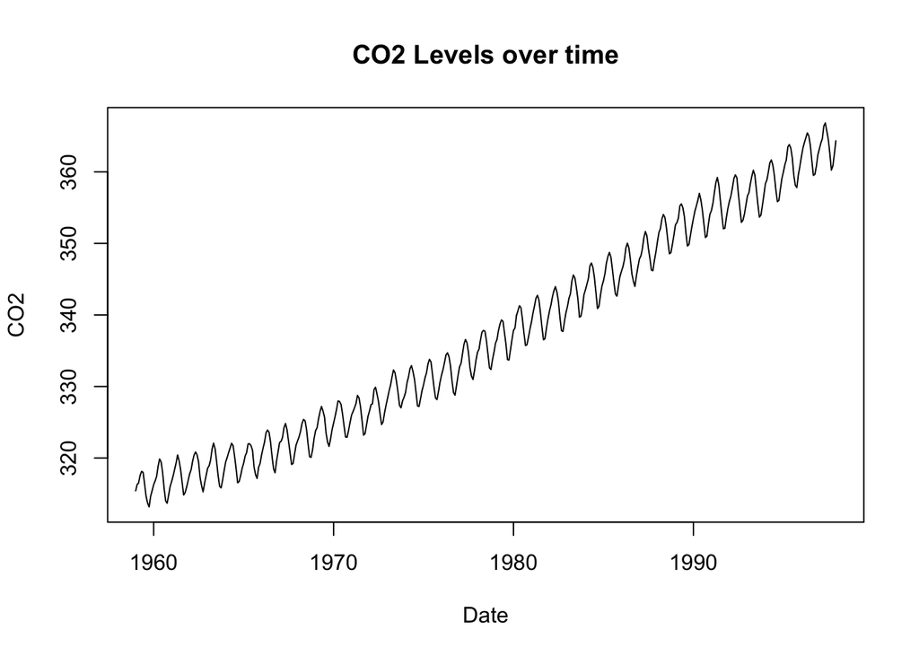

```r
plot(co2_data$ds, co2_data$y, type = "l",
     main = "CO2 Levels over time",
     xlab = "Date", ylab = "CO2")
```

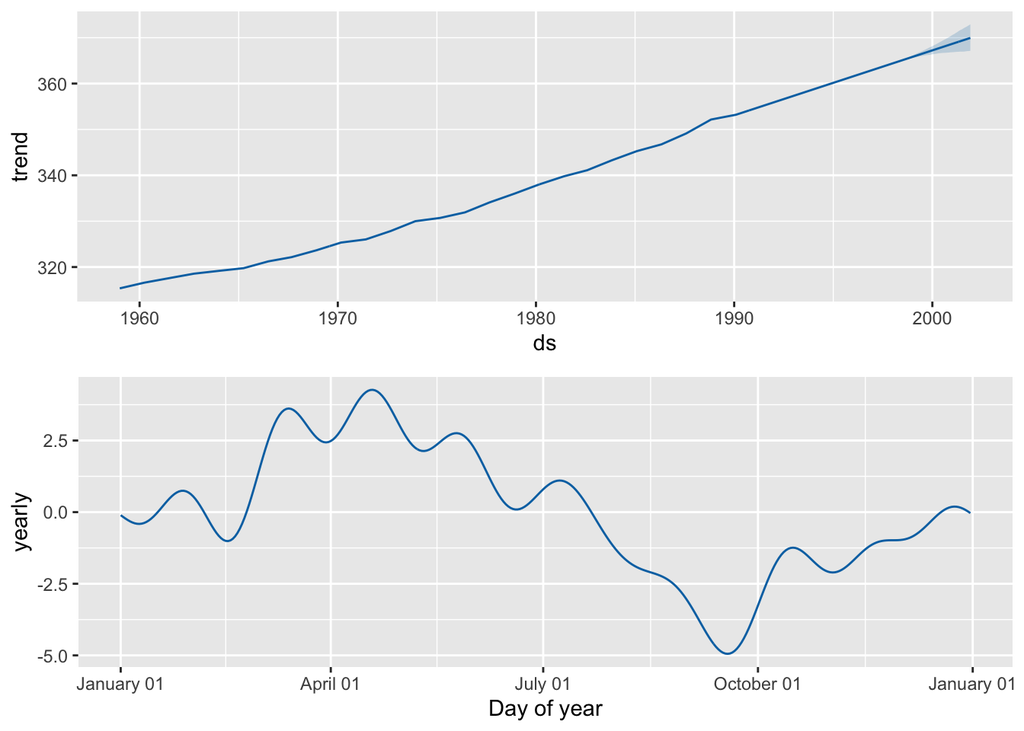

```r
prophet_plot_components(ts_model, forecast)
```

# **Small Real-World Case - Romania**

Rising CO2 levels are an important global issue linked to climate change. Similar trends can also be observed in European countries, including Romania, the country I am from. According to environmental reports, CO2 emissions have shown long-term increases, although policies aim to reduce them.

As this project is carried out in Romania, it is interesting to relate the global CO2 trend to regional patterns. While this dataset is global, it reflects broader environmental concerns that are also relevant locally.

```r
trend_model <- lm(y ~ ds, data = co2_data)
summary(trend_model)
```

```
##
## Call:
## lm(formula = y ~ ds, data = co2_data)
##
## Residuals:
##     Min      1Q  Median      3Q     Max
## -6.0413 -1.9469  0.0004  1.9106  6.5161
##
## Coefficients:
##              Estimate Std. Error t value Pr(>|t|)
## (Intercept) 3.260e+02  1.514e-01  2153.2   <2e-16 ***
## ds          3.580e-03  2.944e-05   121.6   <2e-16 ***
## ---
## Signif. codes:  0 '***' 0.001 '**' 0.01 '*' 0.05 '.' 0.1 ' ' 1
##
## Residual standard error: 2.619 on 466 degrees of freedom
## Multiple R-squared:  0.9694, Adjusted R-squared:  0.9694
## F-statistic: 1.478e+04 on 1 and 466 DF,  p-value: < 2.2e-16
```

According to data from the World Bank, Romania has experienced changes in CO2 emissions over time, reflecting broader environmental and economic trends.

The following link is a very interesting article about CO2 and Greenhouse Gas Emissions in Romania: https://ourworldindata.org/profile/co2/romania

# **Conclusion**

In conclusion, the Prophet model was able to capture the main patterns in the CO2 data, including both the upward trend and seasonal variation. The results suggest that CO2 levels are likely to continue increasing over time. Overall, the model provides a reasonable forecast and helps to better understand the behaviour of the series.